# Testing the assumptions of SLR and introducing new variables

# SLR: testing the assumptions

We are going to test the assumptions for the regression analysis carried out on the dataset *cars*. We already know that we can extract the coefficients from the object containing the results of the regression analysis:

```r
data(cars)
cars.lm <- lm(dist ~ speed, data = cars)
coef(cars.lm)
```

```
## (Intercept)       speed
##  -17.579095    3.932409
```

```r
names(cars.lm)
```

```
##  [1] "coefficients"  "residuals"     "effects"       "rank"
##  [5] "fitted.values" "assign"        "qr"            "df.residual"
##  [9] "xlevels"       "call"          "terms"         "model"
```

We can do the same for the residuals, and we can plot them:

```r
residuals(cars.lm)
```

```
##          1          2          3          4          5          6          7
##   3.849460  11.849460  -5.947766  12.052234   2.119825  -7.812584  -3.744993
##          8          9         10         11         12         13         14
##   4.255007  12.255007  -8.677401   2.322599 -15.609810  -9.609810  -5.609810
##         15         16         17         18         19         20         21
##  -1.609810  -7.542219   0.457781   0.457781  12.457781 -11.474628  -1.474628
##         22         23         24         25         26         27         28
##  22.525372  42.525372 -21.407036 -15.407036  12.592964 -13.339445  -5.339445
##         29         30         31         32         33         34         35
## -17.271854  -9.271854   0.728146 -11.204263   2.795737  22.795737  30.795737
##         36         37         38         39         40         41         42
## -21.136672 -11.136672  10.863328 -29.069080 -13.069080  -9.069080  -5.069080
##         43         44         45         46         47         48         49
##   2.930920  -2.933898 -18.866307  -6.798715  15.201285  16.201285  43.201285
##         50
##   4.268876
```

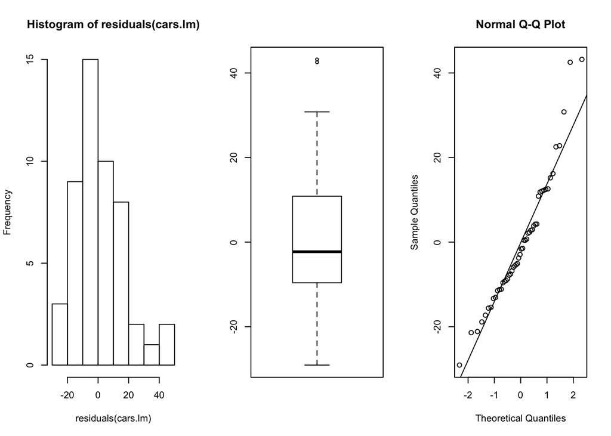

```r
par(mfrow=c(1,3))
hist(residuals(cars.lm))
boxplot(residuals(cars.lm))
qqnorm(residuals(cars.lm))
qqline(residuals(cars.lm))
```

```r
par(mfrow=c(1,1))
```

In general, to test for problems with the model residuals, we can simply plot the results of the regression analysis:

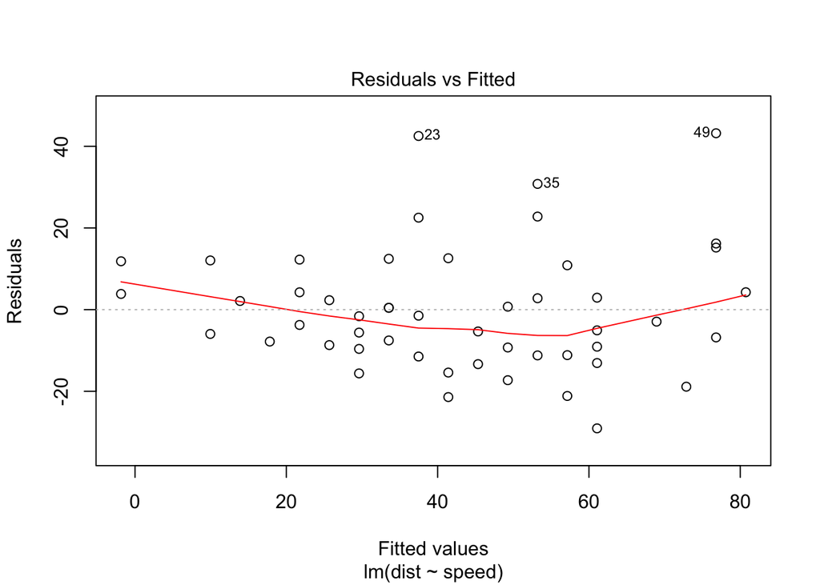

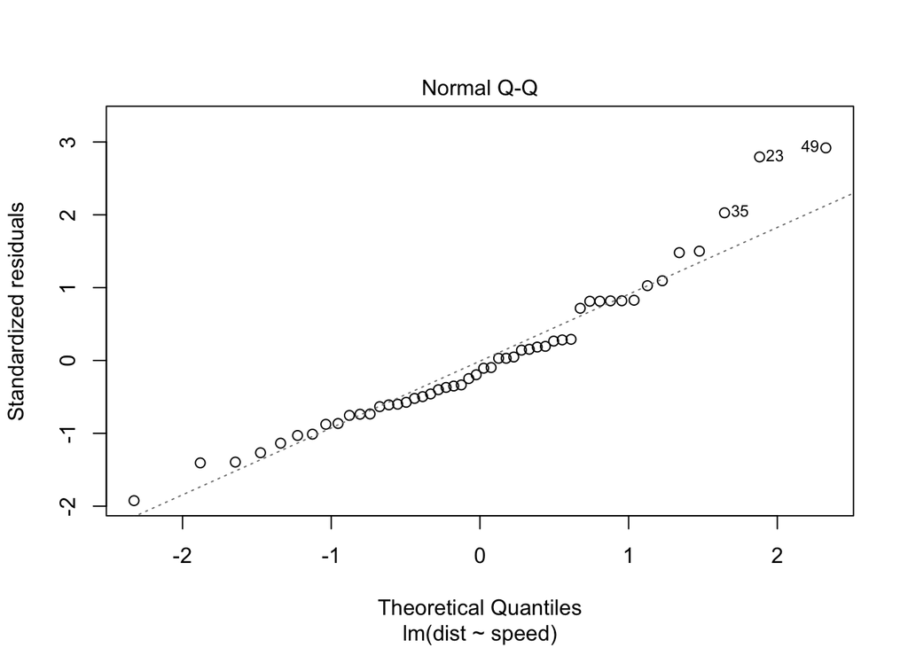

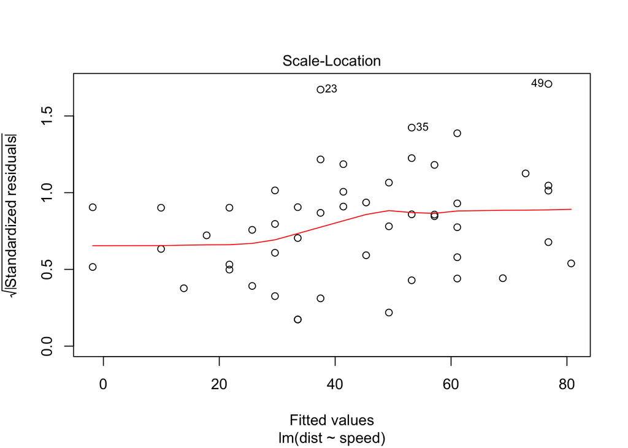

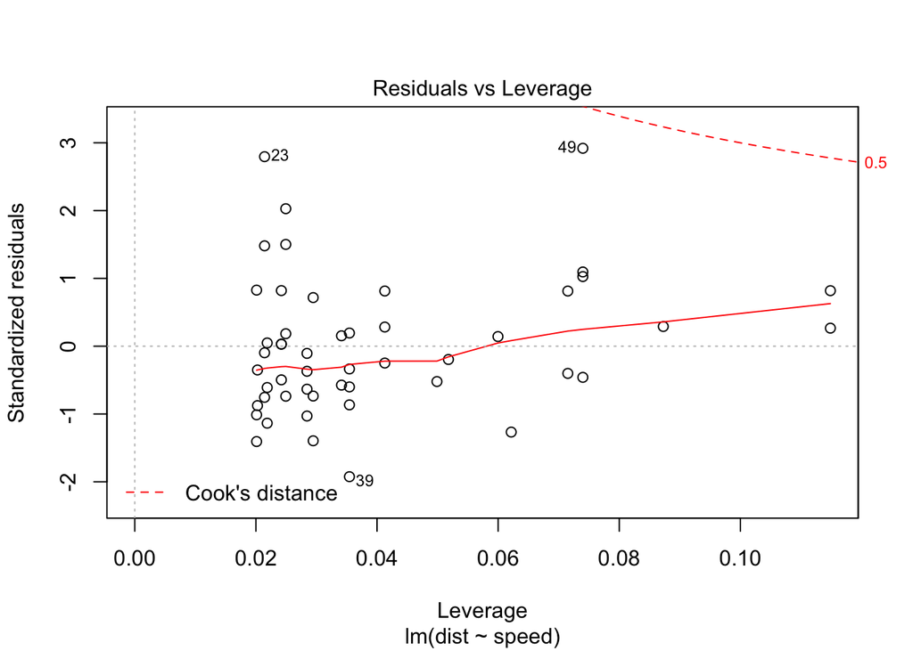

```r
plot(cars.lm)
```

## Independence assumption

One of the strongest regression assumptions is the one regarding independence. Departures from the independence assumption are often exhibited by correlation (or autocorrelation) present in the residuals. There can be positive or negative correlation.  
To check this assumption, we use the first plot and we watch out for any patterns or structure: the points should be randomly scattered on the plot.  
We can also do a test for this:

```r
# install.packages("lmtest")
library(lmtest)
dwtest(cars.lm, alternative = "two.sided")
```

```
##
##  Durbin-Watson test
##
## data:  cars.lm
## DW = 1.6762, p-value = 0.1904
## alternative hypothesis: true autocorrelation is not 0
```

In this case, we do not reject the null hypothesis. There is very little evidence of nonzero autocorrelation in the residuals.

## Normality assumption

We can identify poins that do not fall on the qqline:

```r
cars[23,]
```

```
##    speed dist
## 23    14   80
```

```r
dim(cars)
```

```
## [1] 50  2
```

```r
cars[-23,]
```

```
##    speed dist
## 1      4    2
## 2      4   10
## 3      7    4
## 4      7   22
## 5      8   16
## 6      9   10
## 7     10   18
## 8     10   26
## 9     10   34
## 10    11   17
## 11    11   28
## 12    12   14
## 13    12   20
## 14    12   24
```

[output cut: 35 more lines]

```r
dim(cars[-23,])
```

```
## [1] 49  2
```

Of course, the normality of the residuals can be checked with a Shapiro test:

```r
shapiro.test(residuals(cars.lm))
```

```
##
##  Shapiro-Wilk normality test
##
## data:  residuals(cars.lm)
## W = 0.94509, p-value = 0.02152
```

For this data, we would reject the assumption of normality of the residuals - but the regression model is reasonably robust to departures from the normality assumptions. As long as the residual distribution is not highly skewed, the regression estimators will perform reasonably well.

## Constant variance assumption

To check for the variance of the residuals, we use the scale-location plot. In this plot, we should watch out for any fanning out (or in) of the dots. Hopefully, they fall in a constant band.  
We can also perform a test, which is called the studentized Breusch-Pagan test:

```r
library(lmtest)
bptest(cars.lm)
```

```
##
##  studentized Breusch-Pagan test
##
## data:  cars.lm
## BP = 3.2149, df = 1, p-value = 0.07297
```

## BoxCox transformation

```r
data("trees")
head(trees)
```

```
##   Girth Height Volume
## 1   8.3     70   10.3
## 2   8.6     65   10.3
## 3   8.8     63   10.2
## 4  10.5     72   16.4
## 5  10.7     81   18.8
## 6  10.8     83   19.7
```

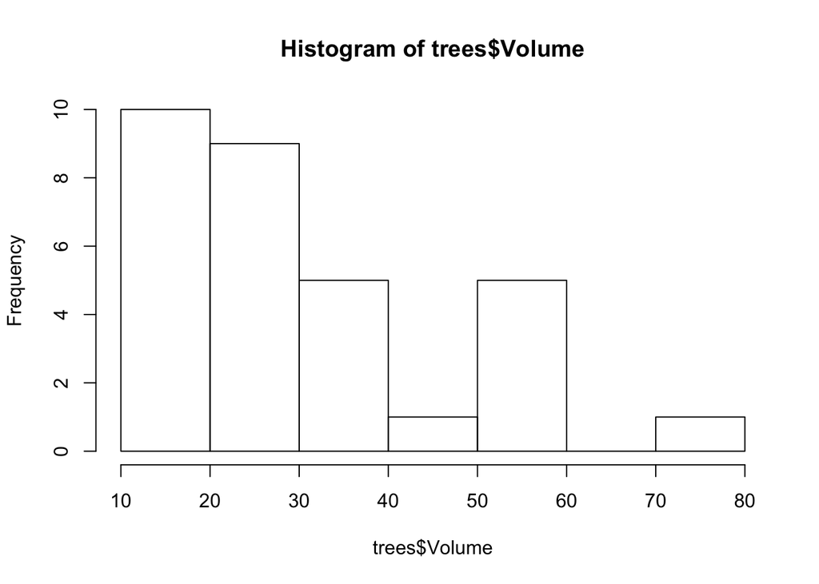

```r
hist(trees$Volume)
```

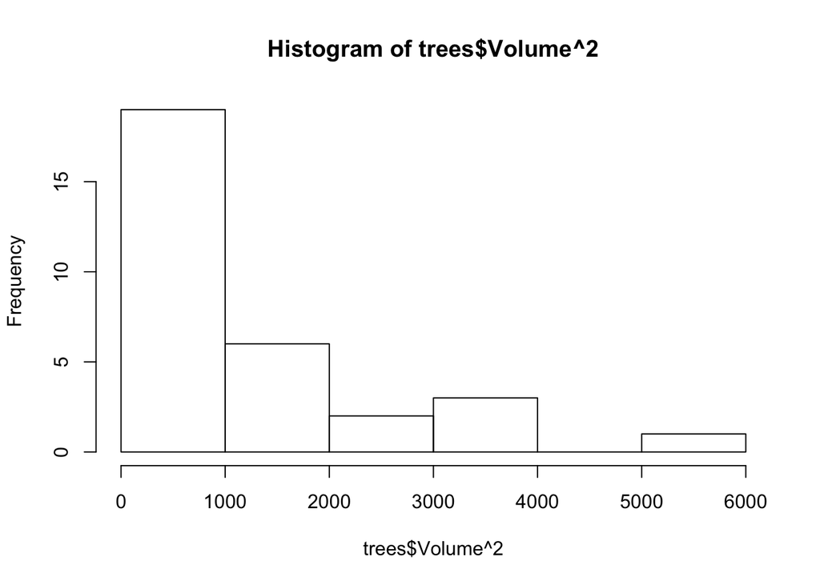

```r
hist(trees$Volume^2)
```

```r
library(MASS)
?boxcox
bctrans <- boxcox(Volume ~ Height + Girth, data = trees)
```

[figure not shown]

```r
bctrans <- boxcox(Volume ~ Height + Girth, data = trees,
                  lambda = seq(0, 0.5, length = 10))
```

[figure not shown]

```r
bctrans
```

[output not shown]

[output cut: 18 more lines]

```r
which(bctrans$y==max(bctrans$y))
```

```
## [1] 62
```

```r
bctrans$x[62]
```

```
## [1] 0.3080808
```

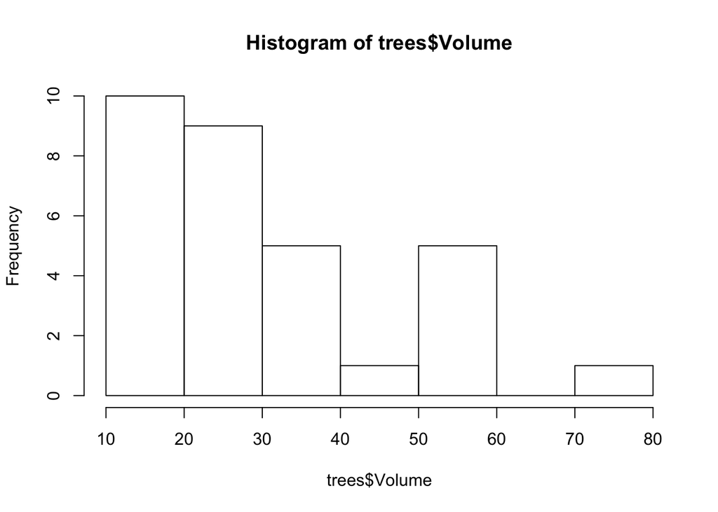

```r
hist(trees$Volume)
```

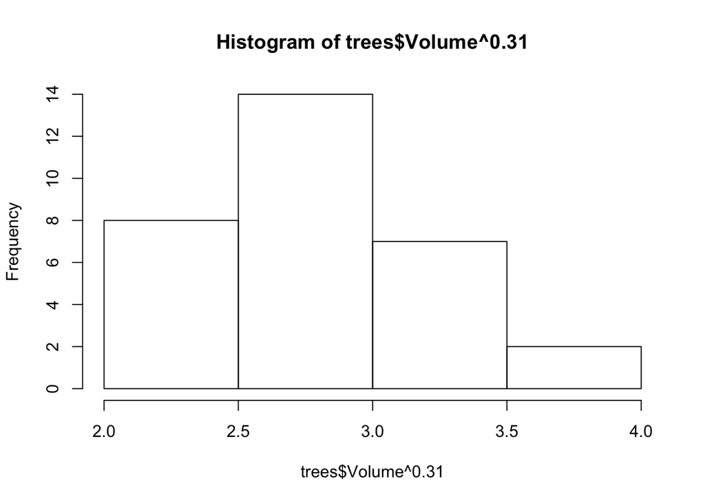

```r
hist(trees$Volume^0.31)
```